# heatmap_fts

Jordan Lee

11/24/2020

# TMP GDAN working group

## Figure 4 Suggestion

### Question

We see (in other figures) that different teams have similar high classification performance. Is this similar performance due to selection of the same feature sets?

### Rationale

If we see teams picking different features, this suggests that there are multiple biomarkers that can predict cancer subtype well. An alternative explaination if we see teams picking different features, is that perhaps there is some relationship (correlation, biological pathway connection, etc.) between features so in a sense the teams are picking the “same” features if they are correlated.

In this analysis we will address the first part: are groups picking the same features?

- `TODO:` And we will dabble in exploring feature relationships (through dissimilarity). From clustering on a dissimilarity matrix.

### Analysis

The preprocessing and generation of these files was conducted in a custom python pipeline. A summary of the pipeline is:

1. Pick a cancer cohort (here we picked breast cancer)
2. Select the best model from each of the 5 teams (JadBIO, SubSCOPE, AKLIMATE, Sci-Kit Grid, and Cloud Forest). Based on highest mean overall weighted F1 score
3. Pull the corresponding feature set from each model
4. Map features to molecular file (based on Theo’s tarball)
5. Cluster feature rows, no clustering of sample columns. Clustering done on molecular file

Note in calculating z-scores, NAs were omitted

```r
###### Hardcoded
cancer <- 'BRCA'
df <- fread('../data/heatmap/BRCA_fts_by_VALUE.tsv') %>% as.data.frame()
df_fts <- fread('../data/heatmap/BRCA_fts_by_TEAM.tsv')%>% as.data.frame()
######
```

### Scaled where appropriate - heatmap

Scaling data - METH, GEXP, and MIR

Non-scaled data - MUTA, CNVR

I want to see the differences between features. Data was scaled - all samples for a given feature have mean 0 and sd 1. then ran through normal pipeline

**Analysis Results**

```r
##### hardcoded
yes_scale <- c('N:METH' , 'N:GEXP','N:MIR') # which fts to scale
#####
```

```
#{r mixed scaled z score loop for all data types}
####
# Main
####
pre <- c('I:CNVR', 'N:METH' , 'N:GEXP', 'B:MUTA', 'N:MIR')

for (prefix in pre){
  # A. Order by subtype
  df_transform <- df %>% arrange(Labels)

  # B. Column annotation
  column_ha <- HeatmapAnnotation(
    Subtype = df_transform$Labels,
    na_col = 'grey',
    col = list(
      Subtype = c(
        "BRCA_1" = 'orange',
        "BRCA_2"='sienna1',
        "BRCA_3"='red',
        "BRCA_4"='red4'
      )
    )
  )

  # C. Select data type
  df_transform <- df_transform %>%
      select(-Labels) %>%
      select(-all_of(cancer)) %>%
      select(starts_with(prefix))
  mat <- df_transform %>%
      as.matrix() %>%
      t()
  print(prefix)
  n_fts <- nrow(mat)
  print(n_fts)

  # 1. Heatmap that applies clustering we want
  #    second heatmap same row/col order but with added annotation bars

  # scale if appropriate
```

[output cut: 76 more lines]

```
  # unit tests
  #####
  # sanity check 1 - that the row orders are the same in the two heatmaps
  assert('Assertion Error: order of feature rows on heatmap and final heatmap not same', rownames(mat2) == ftnames_order)
  # sanity check 2 - directly compare heatmap rows
  heatmap_order <- row_order(fig) # index vector
  ftnames_order2 <- c() # featurename vector
  for (i in heatmap_order){
    add_ft <- rownames(mat2)[i]
    ftnames_order2 <- c(ftnames_order2, add_ft)
  }
  assert('Assertion Error: order of feature rows on heatmap and final heatmap not same', ftnames_order2 == ftnames_order)

  print(paste('Distance metric = ', fig@row_dend_param$distance, '. Method = ', fig@row_dend_param$method, sep=' '))
}
```

```
## [1] "N:MIR"
```

```
## [1] 14
```

```
##  [1] "N:MIR::hsa-let-7c-5p:Corrected:"    "N:MIR::hsa-miR-181c-5p:Corrected:"
##  [3] "N:MIR::hsa-miR-934:Corrected:"      "N:MIR::hsa-miR-18a-5p:Corrected:"
##  [5] "N:MIR::hsa-miR-135b-3p:Corrected:"  "N:MIR::hsa-miR-4677-3p:Corrected:"
##  [7] "N:MIR::hsa-miR-1307-3p:Corrected:"  "N:MIR::hsa-miR-185-5p:Corrected:"
##  [9] "N:MIR::hsa-miR-342-5p:Corrected:"   "N:MIR::hsa-miR-190b:Corrected:"
## [11] "N:MIR::hsa-miR-4668-3p:Corrected:"  "N:MIR::hsa-miR-4728-3p:Corrected:"
## [13] "N:MIR::hsa-miR-30c-2-3p:Corrected:" "N:MIR::hsa-miR-30a-5p:Corrected:"
```

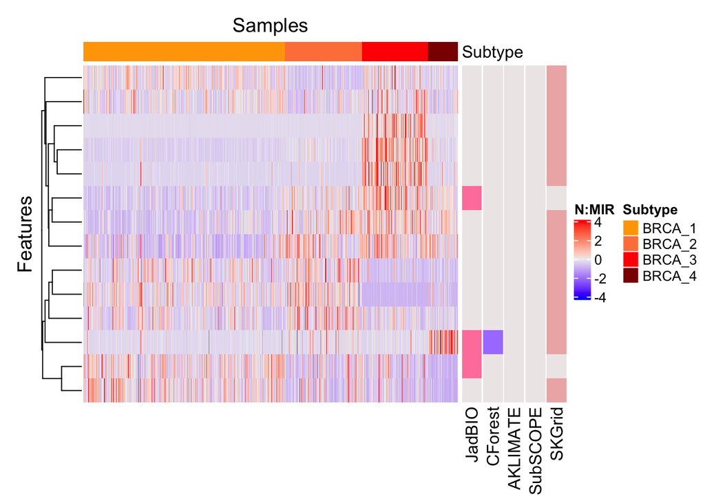

```
## [1] "Distance metric =  euclidean . Method =  complete"
```

**look here**

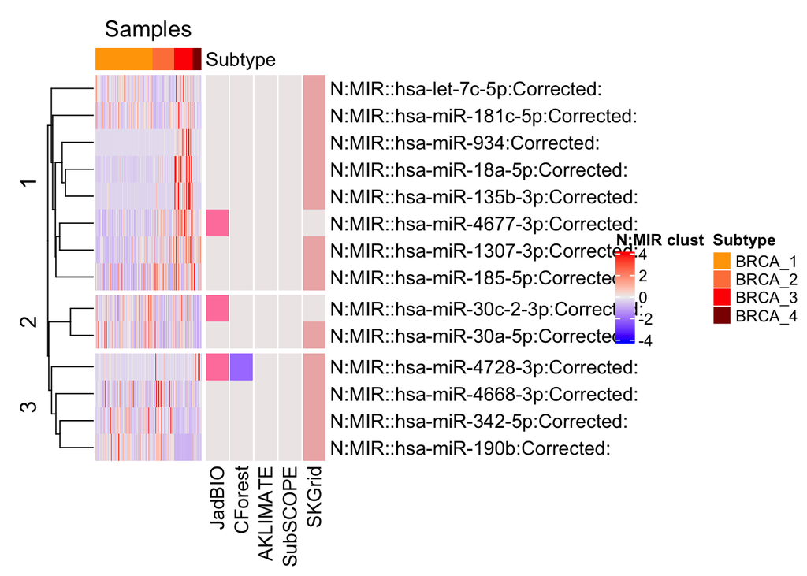

```
## [1] 1
```

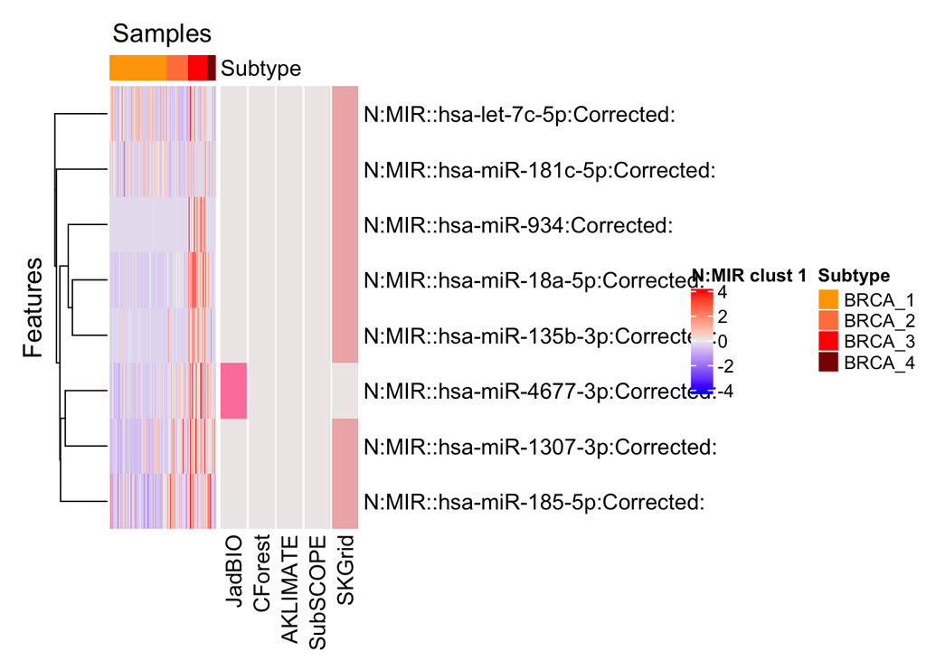

```
## [1] 2
```

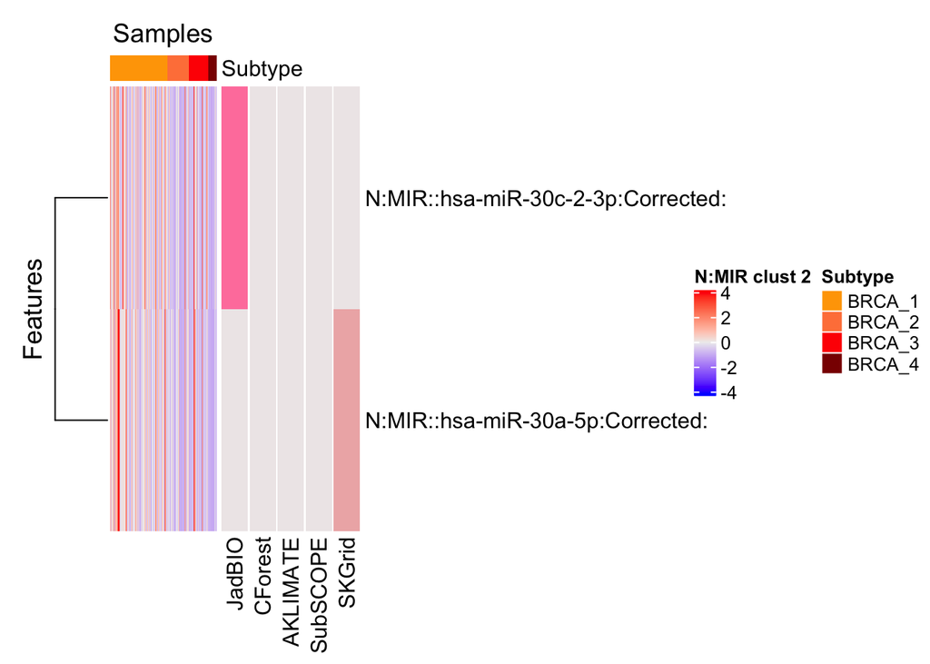

```
## [1] 3
```

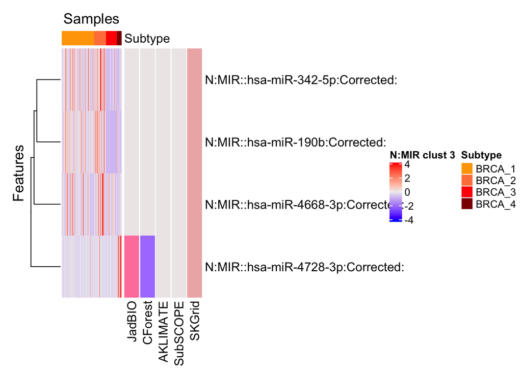

now zoom in on a section

[output not shown]

[output not shown]

# old

Adding `row_split` in heatmap function

**NOTE THIS WILL CHANGE THE ROW ORDER but using as an approximate on where to zoom in on the heatmap**

Now zoom in on certain clusters

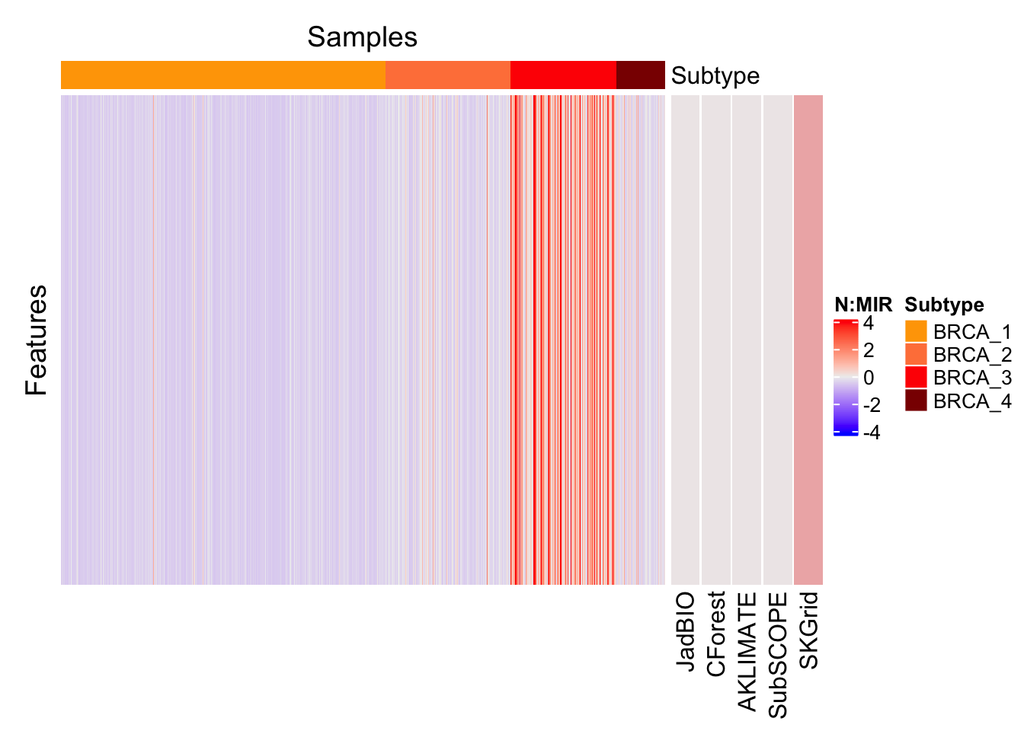

```r
# grab rownames of all rows in a cluster
all_rows <- row_order(fig)[[4]]

# rerun without spliting rows - this is needed input for subsetting fig
fig <- Heatmap(
  mat2, #each col will have mean 0, sd 1
  name = prefix,
  cluster_rows = TRUE,
  cluster_columns = FALSE,
  show_row_names = FALSE,
  show_column_names = FALSE,
  column_title = 'Samples',
  row_title = 'Features',
  top_annotation = column_ha,
  right_annotation = team_list,
  # row_split = 5,
  # row_title = "%s"
)

# subset and show heatmap
fig[min(all_rows):max(all_rows),]
```

### ARCHIVED Raw unscaled data - heatmap

**Analysis Results**

```r
####
# Main
####
# prefix <- 'I:CNVR'
pre <- c('I:CNVR', 'N:METH' , 'N:GEXP', 'B:MUTA', 'N:MIR')
for (prefix in pre){
  # A. Order by subtype
  df_transform <- df %>% arrange(Labels)

  # B. Column annotation
  column_ha <- HeatmapAnnotation(
    Subtype = df_transform$Labels,
    na_col = 'grey',
    col = list(
      Subtype = c(
        "BRCA_1" = 'royalblue4',
        "BRCA_2"='royalblue1',
        "BRCA_3"='paleturquoise3',
        "BRCA_4"='paleturquoise1'
      )
    )
  )

  # C. Select data type
  df_transform <- df_transform %>%
      select(-Labels) %>%
      select(-all_of(cancer)) %>%
      select(starts_with(prefix))
  mat <- df_transform %>%
      as.matrix() %>%
      t()
  print(prefix)
  n_fts <- nrow(mat)
  print(n_fts)

  # 1. Heatmap that applies clustering we want
  #    second heatmap same row/col order but with added annotation bars
  fig <- Heatmap(
    mat,
    name = 'first heatmap',
    cluster_rows = TRUE,
    cluster_columns = FALSE,
    show_row_names = FALSE,
    show_column_names = FALSE,
    column_title = 'Samples',
    row_title = 'Features',
    top_annotation = column_ha
  )
  draw(fig)

  ####
  # new
  ####

  # Ordering
  # 1. Get order of features post heatmap clustering
  heatmap_order <- row_order(fig) # index vector
  ftnames_order <- c() # featurename vector
  for (i in heatmap_order){
    add_ft <- colnames(df_transform)[i]
    ftnames_order <- c(ftnames_order, add_ft)
  }
  print(ftnames_order)
  # 2. Get new matrix that is ordered by heatmap clustering
  mat2 <- mat[match(ftnames_order, rownames(mat)),]



  # Build annotation bars of teams feature sets.
  # 1. df of all teams. match ft order in heatmap
  team_df<- df_fts %>% filter(featureID %in% ftnames_order) %>% arrange(match(featureID, ftnames_order))
  # 2. Pull just the team of interest
  jadbio <- team_df %>% pull('gnosis_1_BRCA') %>% as.character()
  cforest <- team_df %>% pull('CF|All_Top 100_BRCA') %>% as.character()
  aklimate <- team_df %>% pull('AKLIMATE_BRCA_reduced_model_1000_feature_set_BRCA') %>% as.character()
  subscope <- team_df %>% pull('nn_jg_2020-03-20_top1kfreq:BRCA_BRCA') %>% as.character()
  skgrid <- team_df %>% pull('fbedeBIC_BRCA') %>% as.character()
  team_list <- rowAnnotation(
    JadBIO = jadbio,
    CForest = cforest,
    AKLIMATE = aklimate,
    SubSCOPE = subscope,
    SKGrid = skgrid,
    col = list(
      JadBIO = c('0' = "snow2", '1' = "palevioletred1"),
      CForest =  c('0' = "snow2", '1' = "mediumpurple1"),
      AKLIMATE =  c('0' = "snow2", '1' = "cadetblue1"),
      SubSCOPE =  c('0' = "snow2", '1' = "palegreen2"),
      SKGrid =  c('0' = "snow2", '1' = "rosybrown2")
    ),
    show_legend = FALSE
  )
  # 3. Heatmap
  fig <- Heatmap(
    mat2,
    name = prefix,
    cluster_rows = FALSE,
    cluster_columns = FALSE,
    show_row_names = FALSE,
    show_column_names = FALSE,
    # rect_gp = gpar(col = "white", lwd = 2),
    column_title = 'Samples',
    row_title = 'Features',
    top_annotation = column_ha,
    right_annotation = team_list
  )
  draw(fig)
}
```

### ARCHIVED Scaled data - heatmap

I want to see the differences between features. Data was scaled - all samples for a given feature have mean 0 and sd 1. then ran through normal pipeline

**Analysis Results**

```r
####
# Main
####
pre <- c('I:CNVR', 'N:METH' , 'N:GEXP', 'B:MUTA', 'N:MIR')
for (prefix in pre){
  # A. Order by subtype
  df_transform <- df %>% arrange(Labels)

  # B. Column annotation
  column_ha <- HeatmapAnnotation(
    Subtype = df_transform$Labels,
    na_col = 'grey',
    col = list(
      Subtype = c(
        "BRCA_1" = 'orange',
        "BRCA_2"='sienna1',
        "BRCA_3"='red',
        "BRCA_4"='red4'
      )
    )
  )

  # C. Select data type
  df_transform <- df_transform %>%
      select(-Labels) %>%
      select(-all_of(cancer)) %>%
      select(starts_with(prefix))
  mat <- df_transform %>%
      as.matrix() %>%
      t()
  print(prefix)
  n_fts <- nrow(mat)
  print(n_fts)

  # 1. Heatmap that applies clustering we want
  #    second heatmap same row/col order but with added annotation bars
  scaled_mat <- scale(t(mat), center=TRUE, scale=TRUE) #each ft row will have mean 0, sd 1. omit NAs
  scaled_mat <- t(scaled_mat) #but flip for heatmap looks
  fig <- Heatmap(
    scaled_mat,
    name = 'first heatmap',
    cluster_rows = TRUE,
    cluster_columns = FALSE,
    show_row_names = FALSE,
    show_column_names = FALSE,
    column_title = 'Samples',
    row_title = 'Features',
    top_annotation = column_ha
  )
  # draw(fig) # dont need to draw


  ####
  # Add team annotation bar
  ####
  # Ordering
  # 1. Get order of features post heatmap clustering
  heatmap_order <- row_order(fig) # index vector
  ftnames_order <- c() # featurename vector
  for (i in heatmap_order){
    add_ft <- rownames(scaled_mat)[i]
    ftnames_order <- c(ftnames_order, add_ft)
  }
  print(ftnames_order)
  # 2. Get new matrix that is ordered by heatmap clustering
  mat2 <- scaled_mat[match(ftnames_order, rownames(scaled_mat)),]



  # Build annotation bars of teams feature sets.
  # 1. df of all teams. match ft order in heatmap
  team_df<- df_fts %>% filter(featureID %in% ftnames_order) %>% arrange(match(featureID, ftnames_order))
  # 2. Pull just the team of interest
  jadbio <- team_df %>% pull('gnosis_1_BRCA') %>% as.character()
  cforest <- team_df %>% pull('CF|All_Top 100_BRCA') %>% as.character()
  aklimate <- team_df %>% pull('AKLIMATE_BRCA_reduced_model_1000_feature_set_BRCA') %>% as.character()
  subscope <- team_df %>% pull('nn_jg_2020-03-20_top1kfreq:BRCA_BRCA') %>% as.character()
  skgrid <- team_df %>% pull('fbedeBIC_BRCA') %>% as.character()
  team_list <- rowAnnotation(
    JadBIO = jadbio,
    CForest = cforest,
    AKLIMATE = aklimate,
    SubSCOPE = subscope,
    SKGrid = skgrid,
    col = list(
      JadBIO = c('0' = "snow2", '1' = "palevioletred1"),
      CForest =  c('0' = "snow2", '1' = "mediumpurple1"),
      AKLIMATE =  c('0' = "snow2", '1' = "cadetblue1"),
      SubSCOPE =  c('0' = "snow2", '1' = "palegreen2"),
      SKGrid =  c('0' = "snow2", '1' = "rosybrown2")
    ),
    show_legend = FALSE
  )
  # 3. Heatmap
  fig <- Heatmap(
    mat2, #each col will have mean 0, sd 1
    name = prefix,
    cluster_rows = TRUE,
    cluster_columns = FALSE,
    show_row_names = FALSE,
    show_column_names = FALSE,
    column_title = 'Samples',
    row_title = 'Features',
    top_annotation = column_ha,
    right_annotation = team_list
  )
  draw(fig)

  #####
  # unit tests
  #####
  # sanity check 1 - that the row orders are the same in the two heatmaps
  assert('Assertion Error: order of feature rows on heatmap and final heatmap not same', rownames(mat2) == ftnames_order)
  # sanity check 2 - directly compare heatmap rows
  heatmap_order <- row_order(fig) # index vector
  ftnames_order2 <- c() # featurename vector
  for (i in heatmap_order){
    add_ft <- rownames(mat2)[i]
    ftnames_order2 <- c(ftnames_order2, add_ft)
  }
  assert('Assertion Error: order of feature rows on heatmap and final heatmap not same', ftnames_order2 == ftnames_order)

  print(paste('Distance metric = ', fig@row_dend_param$distance, '. Method = ', fig@row_dend_param$method, sep=' '))
}
```